# Inferência estatística

Otimização para previsão de inscritos em canais do YouTube

Deivison Venicio Souza

Márcio de Liz

Charles Adriano dos Santos

31/maio/2018

```r
library(rmarkdown)
knitr::opts_chunk$set(fig.align="center", cache=TRUE, prompt=FALSE, comment = NA, eval = TRUE)
```

# 1 Descrição da atividade

O conjunto de dados `youtube.csv` apresenta o numero de views e inscritos desde o dia de sua abertura para dois canais de sucesso do YouTube.O objetivo é predizer o número acumulado de inscritos em cada um destes canais para o próximo ano (365 dias). Para isto você decidiu emprestar um modelo biológico do crescimento de bactérias chamado `modelo logístico`, dado pela seguinte equação:

$$y = \frac{L}{1 + e^{(\beta(x - \beta_0))}}$$

Em que:

$L$ = é o valor máximo da curva;

$\beta_0$ = o valor de x no ponto médio da curva; e

$\beta$ = declividade da curva.

Assim, pede-se a solução para as seguintes questões:

- Proponha e descreva um algoritmo para ajustar este modelo aos dados disponíveis.
- Ajuste o modelo aos dados dos canais e reporte a sua predição de forma gráfica.

# 2 Carregando pacotes

```r
library(easypackages)
libraries("ggplot2","ggthemes","data.table", "dplyr", "cowplot")
```

# 3 Carregando dados (YouTube)

```r
#carrega os dados
dados <- read.table("youtube.txt", header = T, sep="")

#apenas p/ tranformar p/ minúsculo
colnames(dados) <- tolower(colnames(dados))

#apenas customizando os nomes dos canais
dados$canal <- with(dados,ifelse((canal == "inventonahora"),"Canal-1" ,"Canal-2"))
```

# 4 Análise exploratória dos dados

```r
str(dados)          # estrutura dos dados
'data.frame':   1457 obs. of  4 variables:
 $ dias     : int  1 2 3 4 5 6 7 8 9 10 ...
 $ views    : int  5200 4600 5200 4400 5100 6200 4800 4500 3700 3700 ...
 $ inscritos: int  66 89 103 87 102 93 61 74 53 70 ...
 $ canal    : chr  "Canal-1" "Canal-1" "Canal-1" "Canal-1" ...
class(dados)        # classe do objeto dados
[1] "data.frame"
names(dados)        # atributos disponíveis
[1] "dias"      "views"     "inscritos" "canal"
table(dados$canal)  # quantidade de observações por canal

Canal-1 Canal-2
    850     607
head(dados)         # 6 primeiras instâncias
```

|  | dias | views | inscritos | canal |
| --- | --- | --- | --- | --- |
| 1 | 1 | 5200 | 66 | Canal-1 |
| 2 | 2 | 4600 | 89 | Canal-1 |
| 3 | 3 | 5200 | 103 | Canal-1 |
| 4 | 4 | 4400 | 87 | Canal-1 |
| 5 | 5 | 5100 | 102 | Canal-1 |
| 6 | 6 | 6200 | 93 | Canal-1 |

```r
tail(dados)         # 6 últimas instâncias
```

|  | dias | views | inscritos | canal |
| --- | --- | --- | --- | --- |
| 2146 | 602 | 916706 | 5745 | Canal-2 |
| 2147 | 603 | 681160 | 6072 | Canal-2 |
| 2148 | 604 | 605734 | 4925 | Canal-2 |
| 2149 | 605 | 475528 | 5295 | Canal-2 |
| 2150 | 606 | 628247 | 5611 | Canal-2 |
| 2151 | 607 | 561964 | 5503 | Canal-2 |

# 5 Frequências acumuladas de inscritos ao longo do tempo

```r
setDT(dados)[,`:=`("fcuminsc"=cumsum(inscritos)/100000),
             by=canal][]
```

| dias | views | inscritos | canal | fcuminsc |
| --- | --- | --- | --- | --- |
| 1 | 5200 | 66 | Canal-1 | 0.00066 |
| 2 | 4600 | 89 | Canal-1 | 0.00155 |
| 3 | 5200 | 103 | Canal-1 | 0.00258 |
| 4 | 4400 | 87 | Canal-1 | 0.00345 |
| 5 | 5100 | 102 | Canal-1 | 0.00447 |
| 6 | 6200 | 93 | Canal-1 | 0.00540 |
| 7 | 4800 | 61 | Canal-1 | 0.00601 |
| 8 | 4500 | 74 | Canal-1 | 0.00675 |
| 9 | 3700 | 53 | Canal-1 | 0.00728 |
| 10 | 3700 | 70 | Canal-1 | 0.00798 |

[output cut: 1447 more lines]

# 6 Visualização gráfica - Número de inscritos ao longo do tempo

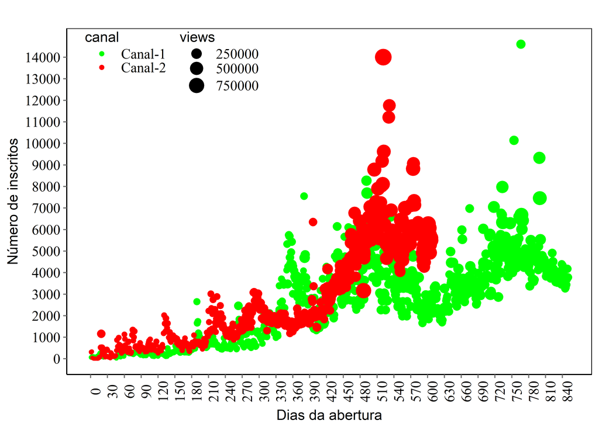

```r
ggplot(data=dados,aes(x=dias,y=inscritos,colour=canal))+
  geom_point(aes(size=views))+
  ggtitle(label="")+ theme_few()+
  scale_color_manual(values=c("green","red"))+
  theme(axis.line.x=element_line(size=0.5,colour="black"),
        axis.line.y=element_line(size=0.5,colour="black"),
        axis.line=element_line(size=1,colour="black"),
        strip.text.x=element_text(colour="black",size=12,family="serif",face="bold"),
        strip.background = element_rect(colour="black", fill="snow2"),
        panel.grid.major=element_blank(),
        panel.grid.minor=element_blank(),
        panel.border=element_rect(color="black"),
        panel.background=element_blank(),
        axis.text.x=element_text(colour="black",size=12,family="serif",angle=90),
        axis.text.y=element_text(colour="black",size=12,family="serif"),
        #legend.position="none",
        legend.position=c(0.2,0.9),
        legend.box = "horizontal",
        legend.direction="vertical",
        legend.justification="center",
        legend.key=element_rect(fill="white",colour="white"),
        legend.text=element_text(size=12,colour="black",family="serif"),
        legend.key.size=unit(1,"cm"),
        legend.key.height=unit(0.8,"line"),
        legend.margin=margin(t=0,r=0,b=0,l=0,unit="cm"),
        legend.title=element_text(),
        plot.title=element_text(hjust=0.50,size=16,face="bold",family="serif"),
        plot.subtitle=element_text(hjust=0.50,size=12,face="italic",family="serif"))+
  scale_x_continuous(name="Dias da abertura",
                     breaks=c(seq(from=0,
                                  to=max(dados$dias),
                                  by=30)),
                     limits=c(0,max(dados$dias)))+
  scale_y_continuous(name="Número de inscritos",
                     breaks=c(seq(from=0,
                                  to=max(dados$inscritos),
                                  by=1000)),
                     limits=c(0,max(dados$inscritos)))
```

# 7 Visualização gráfica - Curva acumulada de inscritos ao longo do tempo

Inicialmente, faz-se uma manipulação dos dados usando a função `melt` do pacote `data.table` (Dowle & Srinivasan, 2017) possibilitando, assim, o uso do argumento `facet_wrap` do pacote `ggplot2` (Wickham, 2009).

```r
melt<-melt(dados,id.vars = c("canal", "dias"), measure.vars = "fcuminsc",
        value.factor = TRUE, variable.name = "variable",
        value.name = "fcum", na.rm = TRUE)
```

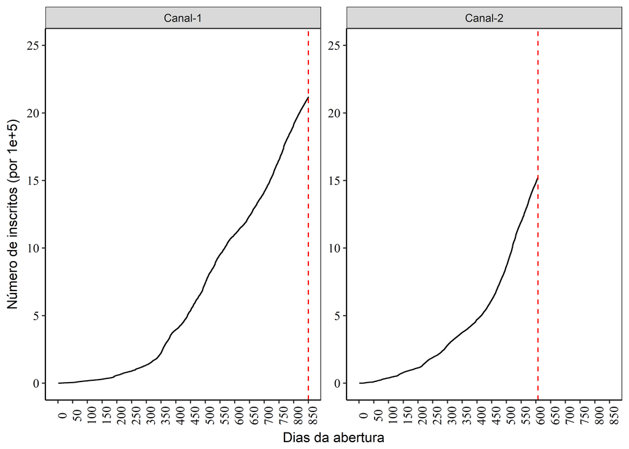

```r
ggplot(melt, aes(x=dias, y=fcum)) + geom_step() +
  geom_vline(data=filter(melt, canal=="Canal-1"),
             aes(xintercept=which.max(subset(dados, canal == "Canal-1")$dias)),
             colour="red", linetype = "dashed") +
  geom_vline(data=filter(melt, canal=="Canal-2"),
               aes(xintercept=which.max(subset(dados, canal == "Canal-2")$dias)),
               colour="red", linetype = "dashed") +
  facet_wrap(~canal,scales="free") + theme_bw() +
  theme(axis.line.x=element_line(size=0.5,colour="black"),
        axis.line.y=element_line(size=0.5,colour="black"),
        axis.line=element_line(size=1,colour="black"),
        axis.text.x=element_text(colour="black",size=10,angle=90,family="serif"),
        axis.text.y=element_text(colour="black",size=10,family="serif"),
        panel.grid.major=element_blank(),
        panel.grid.minor=element_blank(),
        panel.border=element_rect(),
        panel.background=element_blank(),
        plot.title=element_text(hjust=0.50,size=14,face="bold",family="serif"),
        plot.subtitle=element_text(hjust=0.50, size=12,face="italic",family="serif"),
        legend.text=element_text(size=12,colour="black",family="serif"),
        legend.position=c(0.80,0.1),
        legend.margin=margin(1,1,1,1),
        legend.title=element_blank(),
        legend.direction="horizontal")+
  scale_y_continuous(name="Número de inscritos (por 1e+5)",
                     breaks=c(seq(from=0,
                                  to=25,
                                  by=5)),
                     limits=c(0,25))+
  scale_x_continuous(name="Dias da abertura",
                     breaks=c(seq(from=0,
                                  to=max(dados$dias),
                                  by=50)),
                     limits=c(0,max(dados$dias)))
```

# 8 Divide o conjunto de dados para modelagem

Para realizar o procedimento de otimização para canal é necessário a divisão dos dados. Isso, foi feito utilizando-se da função `subset` do R-base (R Core Team, 2017).

```r
Canal.1 <- subset(dados, canal == "Canal-1")
Canal.2 <- subset(dados, canal == "Canal-2")
```

# 9 Modelos testados e função perda

O processo de otimização foi feito com os modelos linear e logístico. A variável **y** de interesse para previsão foi o acumulado do número de inscritos ao longo do tempo e a variável preditora **x** foi o tempo de abertura do canal (dias). A otimização foi feita para cada canal usando a função **optim**. A função perda quadrática foi utilizada para avaliar a bondade dos modelos.

**1. Modelo Linear** (usando perda quadrática)

Aqui, cria-se uma função que define o `modelo linear` a ser otimizado e, ainda, a função perda quadrática (SQ) para avaliar a bondade do ajuste. A modelo linear possui dois parâmetros ($\beta$ e $\beta_0$). Além disso, é necessário fornecer o valor da variável de previsão `y` (frequência acumulada do número de inscritos) e o valor da covariável `x` (dias de abertura do canal).

$$y = \beta + \beta_0\ dias$$

```r
f_ols <- function(par, y, x,...) {
  mu <- par[1] + par[2]*x
  SQ <- sum((y - mu)^2)
  return(SQ)
}
```

**2. Modelo logístico** (usando perda quadrática)

Aqui, cria-se uma função que define o `modelo logístico` a ser otimizado e, ainda, a função perda quadrática (SQ) para avaliar a bondade do ajuste. A modelo logístico possui três parâmetros ($L$, $\beta$ e $\beta_0$). Além disso, é necessário fornecer o valor da variável de previsão `y` (frequência acumulada do número de inscritos) e o valor da covariável `x` (dias de abertura do canal).

$$y = \frac{L}{1 + e^{(\beta(dias - \beta_0))}}$$

Em que:

$L$: valor máximo da curva; = `par[1]`

$\beta$: declividade da curva; = `par[2]`

$\beta_0$: valor de x no ponto médio da curva. = `par[3]`

```r
f_logit <- function(par, y, x,...) {
  mu <- par[1] / (1 + exp(par[2]*(x - par[3])))
  SQ_logit <- sum((y - mu)^2)
  return(SQ_logit)
}
```

# 10 Aplicando a otimização

- Argumentos da função `optim()`:

`par` = Valores iniciais estipulados para os parâmetros a serem otimizados;

`fn` = Uma função a ser minimizada (ou maximizada), com o primeiro argumento o vetor de parâmetros sobre os quais a minimização deve ocorrer. Deve retornar um resultado escalar;

`gr` = Uma função para retornar o gradiente para os métodos “BFGS”, “CG” e “L-BFGS-B”. Se for NULL,uma aproximação de diferenças finitas será usada;

Para o método “SANN”, especifica uma função para gerar um novo ponto candidato. Se for NULL, um kernel Gaussian Markov padrão é usado;

`method` = o metodo a ser usado. O método padrão é uma implementação de Nelder e Mead (1965), que usa apenas valores de função e é robusto, mas relativamente lenta. Funcionará razoavelmente bem para funções não diferenciáveis.

- Retorno da função `optim()` (valores retorno)

`par` = retorna um vetor com o melhor conjunto de parâmetros encontrados;

`value` = retorna o valor de fn corresponde ao par;

`count` = Um vetor inteiro de dois elementos que indica o número de chamadas para fn e gr, respectivamente;

`convergence` = **0** indica conclusão bem-sucedida (que é sempre o caso de “SANN” e “Brent”); e

`message` = Uma cadeia de caracteres que fornece informações adicionais retornadas pelo otimizador ou **NULL**.

## 10.1 Canal 1

### 10.1.1 Modelo Linear (usando perda quadrática)

- Usando a função `optim` (Nelder e Mead (1965)):

```r
fit_ols_C1 <- optim(par = c(0,0),
                    fn = f_ols,
                    y = Canal.1$fcuminsc,
                    x = Canal.1$dias)
fit_ols_C1
$par
[1] -4.21846255  0.02596341

$value
[1] 2962.397

$counts
function gradient
      91       NA

$convergence
[1] 0

$message
NULL
```

### 10.1.2 Modelo logístico (usando perda quadrática)

- Usando a função `optim` (Nelder e Mead (1965)):

```r
fit_logit_C1 <- optim(par = c(25,-0.007,600),
                      fn = f_logit,
                      y = Canal.1$fcuminsc,
                      x = Canal.1$dias)
fit_logit_C1
$par
[1]  24.20447756  -0.00732769 630.27762659

$value
[1] 247.1548

$counts
function gradient
     281       NA

$convergence
[1] 0

$message
NULL
```

## 10.2 Canal 2

### 10.2.1 Modelo Linear (usando perda quadrática)

- Usando a função `optim` (Nelder e Mead (1965)):

```r
fit_ols_C2 <- optim(par = c(0,0),
                    fn = f_ols,
                    y = Canal.2$fcuminsc,
                    x = Canal.2$dias)
fit_ols_C2
$par
[1] -2.63379587  0.02276248

$value
[1] 1552.313

$counts
function gradient
      83       NA

$convergence
[1] 0

$message
NULL
```

### 10.2.2 Modelo logístico (usando perda quadrática)

- Usando a função `optim` (Nelder e Mead (1965)):

```r
fit_logit_C2 <- optim(par = c(20,-0.001,400),
                      fn = f_logit,
                      y = Canal.2$fcuminsc,
                      x = Canal.2$dias)
fit_logit_C2
$par
[1]  46.717306695  -0.007183362 702.315812354

$value
[1] 35.76586

$counts
function gradient
     371       NA

$convergence
[1] 0

$message
NULL
```

# 11 Obtendo as predições e a prognose para 365 dias

Inicialmente, criou-se dois data tables com 3 colunas (`dias`, `pred_ols`, `pred_logit`). Para coluna dias obteve uma sequência considerando o máximo de dias observados de cada canal + 365 dias. As demais colunas foram preenchidas com `NA` para, posteriormente, receberem as predições do `modelo linear` e `logístico`:

```r
DTpred_C1 <- data.table(dias = with(Canal.1,seq(1, max(dias) + 365)),
                        pred_ols = NA, pred_logit = NA)

DTpred_C2 <- data.table(dias = with(Canal.2,seq(1, max(dias) + 365)),
                        pred_ols = NA, pred_logit = NA)
```

- **Predição** (Canal-1)

```r
DTpred_C1$pred_ols <- fit_ols_C1$par[1] + fit_ols_C1$par[2]*DTpred_C1$dias

DTpred_C1$pred_logit <- fit_logit_C1$par[1]/(1 + exp(fit_logit_C1$par[2]*(DTpred_C1$dias - fit_logit_C1$par[3])))

head(DTpred_C1)
```

| dias | pred_ols | pred_logit |
| --- | --- | --- |
| 1 | -4.192499 | 0.2382333 |
| 2 | -4.166536 | 0.2399680 |
| 3 | -4.140572 | 0.2417152 |
| 4 | -4.114609 | 0.2434751 |
| 5 | -4.088645 | 0.2452476 |
| 6 | -4.062682 | 0.2470329 |

- **Predição** (Canal-2)

```r
DTpred_C2$pred_ols <- fit_ols_C2$par[1] + fit_ols_C2$par[2]*DTpred_C2$dias

DTpred_C2$pred_logit <- fit_logit_C2$par[1]/(1 + exp(fit_logit_C2$par[2]*(DTpred_C2$dias - fit_logit_C2$par[3])))

head(DTpred_C2)
```

| dias | pred_ols | pred_logit |
| --- | --- | --- |
| 1 | -2.611033 | 0.3011467 |
| 2 | -2.588271 | 0.3033036 |
| 3 | -2.565508 | 0.3054759 |
| 4 | -2.542746 | 0.3076636 |
| 5 | -2.519983 | 0.3098669 |
| 6 | -2.497221 | 0.3120859 |

# 12 Visualização gráfica: Curva Real versus Curva Ajustada (Canal-1)

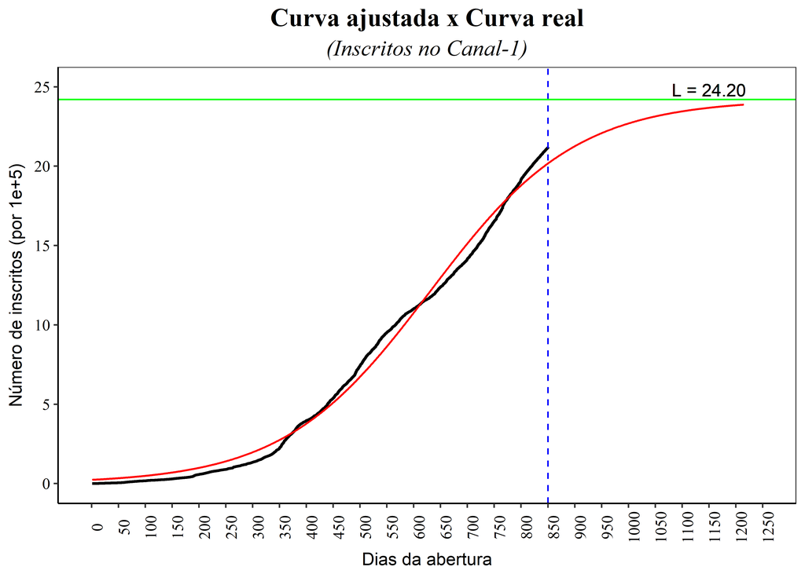

```r
ggplot(Canal.1, aes(x=dias, y=fcuminsc)) + geom_step(linetype=1, lwd=0.8)+
  geom_vline(data=Canal.1,aes(xintercept=which.max(Canal.1$dias)),
             colour="blue", linetype = "dashed")+
  geom_line(data=DTpred_C1,aes(x=dias,y=pred_logit), colour="red",lwd=0.6,lty=1) +
  geom_hline(yintercept=fit_logit_C1$par[1],colour="green",lwd=0.5,lty="solid")+
  ggtitle(label="Curva ajustada x Curva real",subtitle="(Inscritos no Canal-1)")+
  theme_bw() +
  theme(axis.line.x=element_line(size=0.5,colour="black"),
        axis.line.y=element_line(size=0.5,colour="black"),
        axis.line=element_line(size=1,colour="black"),
        axis.text.x=element_text(colour="black",size=10,angle=90,family="serif"),
        axis.text.y=element_text(colour="black",size=10,family="serif"),
        panel.grid.major=element_blank(),
        panel.grid.minor=element_blank(),
        panel.border=element_rect(),
        panel.background=element_blank(),
        legend.position="bottom",
        legend.direction="horizontal",
        legend.justification="center",
        legend.key=element_rect(fill="white",colour="white"),
        legend.text=element_text(size=12,colour="black",family="serif"),
        legend.key.size=unit(1,"cm"),
        legend.key.height=unit(0.8,"line"),
        legend.margin=margin(t=0,r=0,b=0,l=0,unit="cm"),
        legend.title=element_blank(),
        plot.title=element_text(hjust=0.50,size=16,face="bold",family="serif"),
        plot.subtitle=element_text(hjust=0.50,size=14,face="italic",family="serif"))+
  scale_y_continuous(name="Número de inscritos (por 1e+5)",
                     breaks=c(seq(from=0,
                                  to=25,
                                  by=5)),
                     limits=c(0,25))+
  scale_x_continuous(name="Dias da abertura",
                     breaks=c(seq(from=0,
                                  to=max(Canal.1$dias)+400,
                                  by=50)),
                     limits=c(0,max(Canal.1$dias)+400))+
  geom_text(position="identity",
            aes(x = 1150 , y = fit_logit_C1$par[1]+0.6, label = "L = 24.20"))
```